# Laboratorio 1 - AlpesPlanck: Regresión lineal para predicción de temperatura máxima

## Importación de librerías

```python
import pandas as pd
import numpy as np
import unicodedata
import matplotlib.pyplot as plt

from sklearn.model_selection import train_test_split
from sklearn.pipeline import Pipeline
from sklearn.compose import ColumnTransformer
from sklearn.preprocessing import StandardScaler, OneHotEncoder, FunctionTransformer
from sklearn.impute import SimpleImputer
from sklearn.linear_model import LinearRegression
from sklearn.metrics import mean_squared_error, mean_absolute_error, r2_score

from sklearn import set_config
set_config(display="diagram")

pd.set_option('display.max_colwidth', None)
```

## Carga de los datos

```python
datos_laboratorio = pd.read_csv('./data/Datos Lab 1.csv')
data = datos_laboratorio.copy()

diccionario = pd.read_excel('./data/Diccionario de datos.xlsx')
data.shape
```

```
(2576, 27)
```

# 1. Exploración de los datos

Clasificamos primero las variables según su naturaleza estadística, y luego exploramos el dataset con `pandas` para identificar problemas de calidad.

```python
cuantitativas_continuas = [
    'presion_media', 'presion_min', 'presion_max', 'presion_desv',
    'humedad_media', 'humedad_min', 'humedad_max', 'humedad_desv',
    'viento_media', 'viento_min', 'viento_max', 'viento_desv',
    'rafaga_media', 'rafaga_min', 'rafaga_max', 'rafaga_desv',
    'viento_norte', 'viento_este', 'direccion_viento',
    'temp_max_manana',
]

cuantitativas_discretas = [
    'registros_del_dia',
    'anio',
    'dia_del_anio'
]

cualitativas_nominales = [
    'estacion_anio',
    'mes',
    'sector_viento',
    'fecha'
]

cualitativas_ordinales = []
```

### 1.1 Exploración general

A continuación se ejecutan las exploraciones iniciales sobre el dataset, para identificar el porcentaje de datos nulos por variable, ver consistencia de variables categóricas, ver datos repetidos y la validez de dstos.

```python
print(data.describe(include='object'))
```

```
             fecha estacion_anio   mes sector_viento
count         2504          2488  2488          2505
unique        2486            28    61            33
top     2009-01-22     primavera   May            SO
freq             2           517   127           695
```

**Revisar porcentaje de nulidad por variable**

```python
print(((data.isnull().sum() / data.shape[0])).sort_values(ascending=False))
```

```
temp_max_manana      0.036879
viento_min           0.035326
estacion_anio        0.034161
mes                  0.034161
anio                 0.033385
humedad_max          0.033385
viento_media         0.033385
viento_max           0.031444
humedad_min          0.031056
viento_norte         0.031056
presion_desv         0.031056
rafaga_desv          0.030668
direccion_viento     0.030668
rafaga_media         0.030280
registros_del_dia    0.029891
presion_media        0.029115
presion_min          0.028727
humedad_media        0.028727
rafaga_max           0.028339
rafaga_min           0.027950
viento_desv          0.027950
fecha                0.027950
sector_viento        0.027562
dia_del_anio         0.026398
presion_max          0.024845
viento_este          0.024845
humedad_desv         0.023680
dtype: float64
```

**Revisar filas duplicadas**

```python
print(int(data.duplicated(keep=False).sum()))
duplicados = datos_laboratorio[datos_laboratorio.duplicated()]
print(duplicados)
```

```
8
           fecha  presion_media  presion_min  presion_max  presion_desv  \
2556  2013-04-20      1000.4455       998.46      1002.49        1.1632
2559  2012-11-13      1005.3724      1002.77      1006.81        1.0690
2563  2009-01-22      9784.1150       971.48       983.54        3.9853
2565  2013-02-08       984.6369       983.06       987.49        1.3454

      humedad_media  humedad_min  humedad_max  humedad_desv  viento_media  \
2556      60.748100        45.71         82.0       10.9518      17.65908
2559      88.175500        58.28         99.1       12.6853       4.07916
2563      86.731100        69.11         97.6        9.7926      10.09692
2565       0.886056         0.76         96.8        4.6160           NaN

      ...  viento_norte  viento_este  direccion_viento  registros_del_dia  \
2556  ...        4.1573       2.5121           31.1426              144.0
2559  ...       -0.9230      -0.2193          193.3681              144.0
2563  ...       -2.7229      -0.1899          183.9897              144.0
2565  ...        0.0254      -0.2613          275.5529              144.0

        anio  dia_del_anio  estacion_anio      mes  sector_viento  \
2556  2013.0         110.0      primavera  JANUARY             NE
2559  2012.0         318.0          otono    abril              S
2563  2009.0          22.0         verano  octubre              S
2565  2013.0          39.0         verano      Sep              O

      temp_max_manana
2556           61.412
2559           44.852
2563            5.770
2565           -0.600

[4 rows x 27 columns]
```

**Revisar consistencia de variable sector_viento**

```python
print(data['sector_viento'].value_counts())
```

```
sector_viento
SO           695
S            519
NE           424
O            308
N            124
E             77
SE            66
NO            42
Suroeste      29
so            26
SOUTHWEST     24
s             20
South         19
ne            19
NORTHEAST     17
Sur           16
Noreste       12
o              8
SOUTH          8
NORTH          6
no             6
West           5
WEST           5
North          4
East           4
EAST           4
Sureste        3
Oeste          3
Noroeste       3
SOUTHEAST      3
Norte          3
Este           2
NORTHWEST      1
Name: count, dtype: int64
```

**Revisar consistencia de variable mes**

```python
print(data['mes'].value_counts())
```

```
mes
May           127
August        125
July          123
January       120
March         118
             ...
april          16
septiembre     16
junio          16
Jan            13
OCTOBER        13
Name: count, Length: 61, dtype: int64
```

**Revisar consistencia de variable estacion_anio**

```python
print(data['estacion_anio'].value_counts())
```

```
estacion_anio
primavera               517
invierno                511
otono                   500
verano                  487
Inverano                 71
Estacion_Desconocida     63
VERANO_INVIERNO          60
East                     48
VERANO                   19
autumn                   18
primaveraa               17
berano                   17
fall                     15
winter                   15
verno                    14
Otoño                    12
otoño                    11
invernio                 11
Primavera                10
PRIMAVERA                10
invierno                  9
INVIERNO                  9
Verano                    9
Invierno                  9
OTONO                     8
primav                    6
spring                    6
summer                    6
Name: count, dtype: int64
```

**Revisar validez de variables con rangos, usando mínimos y máximos**

```python
print(data.describe())
```

```
       presion_media  presion_min  presion_max  presion_desv  humedad_media  \
count    2501.000000  2502.000000  2512.000000   2496.000000    2502.000000
mean     1010.494271   986.684409   991.704244      1.752041      52.413586
std       435.334494     8.927138     7.726906      1.215931      35.975384
min       948.996000   913.600000   951.940000      0.226900       0.004663
25%       984.287800   981.371333   987.070000      0.899050       0.869060
50%       989.452800   987.070000   991.935000      1.444550      68.558100
75%       994.469000   992.567500   996.782500      2.254800      80.562600
max      9939.918000  1012.320198  1013.940000     12.397500     100.000000

       humedad_min  humedad_max  humedad_desv  viento_media   viento_min  ...  \
count  2496.000000  2490.000000   2515.000000   2490.000000  2485.000000  ...
mean     45.094067    90.236582     10.606821      3.814103     1.417799  ...
std      30.196163    10.647237      5.481338      3.307402     3.960650  ...
min       0.237700    27.020000      0.000000      0.000000     0.000000  ...
25%       1.011790    88.025000      6.082100      1.655350     0.230000  ...
50%      49.670000    93.300000     10.199800      2.463400     0.440000  ...
75%      67.665000    96.600000     14.722200      4.880505     0.960000  ...
max     103.311405   100.000000     26.341600     24.753600    45.184956  ...

        rafaga_min   rafaga_max  rafaga_desv  viento_norte  viento_este  \
count  2504.000000  2503.000000  2497.000000   2496.000000  2512.000000
mean     -2.639322     6.946058    -5.763253     -1.128463    -0.410159
std     199.861693     3.237379    75.258134     25.065084     1.147218
min   -9999.000000     0.000000  -232.260000  -1250.463300    -3.718500
25%       0.440000     4.803198     1.002100     -1.640625    -1.236475
50%       0.660000     6.690000     1.461100     -0.564300    -0.356000
75%       1.120000     8.850000     2.008800      0.241525     0.316275
max      19.895916    23.500000  3471.027800      4.809900     4.713900

       direccion_viento  registros_del_dia         anio  dia_del_anio  \
count       2497.000000        2499.000000  2490.000000   2508.000000
mean         172.104573         144.090836  2011.995582    182.690989
std           86.102348           4.107365     1.999694    105.529469
min            0.000000          90.000000  2009.000000      1.000000
25%           91.303500         144.000000  2010.000000     91.000000
50%          199.568500         144.000000  2012.000000    182.500000
75%          227.101700         144.000000  2014.000000    274.250000
max          359.796700         287.000000  2015.000000    366.000000

       temp_max_manana
count      2481.000000
mean         13.863309
std           9.296199
min         -15.230000
25%           7.310000
50%          14.310000
75%          20.460000
max          63.050000

[8 rows x 23 columns]
```

### 1.2 Evidencia de problemas de **validez** (rangos incorrectos)

Un valor es inválido cuando, aunque esté presente (no es nulo), **no tiene sentido físico** para lo que representa: una humedad relativa no puede superar el 100%, una presión atmosférica no puede ser 10 veces el máximo histórico registrado en la Tierra, una desviación estándar no puede ser negativa, etc. A continuación se contrasta el mínimo y el máximo real de cada variable contra el rango físicamente válido (según el diccionario de datos y la naturaleza del fenómeno).

```python
rangos_validos = {
    'presion_media': (900, 1085),
    'presion_min': (900, 1085),
    'presion_max': (900, 1085),
    'presion_desv': (0, 50),
    'humedad_media': (0, 100),
    'humedad_min': (0, 100),
    'humedad_max': (0, 100),
    'humedad_desv': (0, 100),
    'viento_media': (0, 60),
    'viento_min': (0, 60),
    'viento_max': (0, 60),
    'viento_desv': (0, 60),
    'rafaga_media': (0, 100),
    'rafaga_min': (0, 100),
    'rafaga_max': (0, 100),
    'rafaga_desv': (0, 100),
    'viento_norte': (-60, 60),
    'viento_este': (-60, 60),
    'direccion_viento': (0, 360),     # dic: "de 0 a 360 grados"
    'registros_del_dia': (0, 144),    # dic: "un dia completo tiene 144"
    'anio': (2003, 2015),             # la estacion mide desde 2003
    'dia_del_anio': (1, 366),         # dic: "de 1 a 366"
}

print(f'{"variable":18s} {"min_real":>12s} {"max_real":>12s}  dentro_rango?')
for var, (lo, hi) in rangos_validos.items():
    mn, mx = data[var].min(), data[var].max()
    dentro = (mn >= lo) and (mx <= hi)
    marca = '' if dentro else '  <-- FUERA DE RANGO (problema de validez)'
    print(f'{var:18s} {mn:12.3f} {mx:12.3f}  {str(dentro):>12s}{marca}')
```

```
variable               min_real     max_real  dentro_rango?
presion_media           948.996     9939.918         False  <-- FUERA DE RANGO (problema de validez)
presion_min             913.600     1012.320          True
presion_max             951.940     1013.940          True
presion_desv              0.227       12.398          True
humedad_media             0.005      100.000          True
humedad_min               0.238      103.311         False  <-- FUERA DE RANGO (problema de validez)
humedad_max              27.020      100.000          True
humedad_desv              0.000       26.342          True
viento_media              0.000       24.754          True
viento_min                0.000       45.185          True
viento_max                0.000       45.108          True
viento_desv               0.000     3319.030         False  <-- FUERA DE RANGO (problema de validez)
rafaga_media          -1386.273       11.465         False  <-- FUERA DE RANGO (problema de validez)
rafaga_min            -9999.000       19.896         False  <-- FUERA DE RANGO (problema de validez)
rafaga_max                0.000       23.500          True
rafaga_desv            -232.260     3471.028         False  <-- FUERA DE RANGO (problema de validez)
viento_norte          -1250.463        4.810         False  <-- FUERA DE RANGO (problema de validez)
viento_este              -3.719        4.714          True
direccion_viento          0.000      359.797          True
registros_del_dia        90.000      287.000         False  <-- FUERA DE RANGO (problema de validez)
anio                   2009.000     2015.000          True
dia_del_anio              1.000      366.000          True
```

**Hallazgo:** `presion_media`, `humedad_min`, `viento_desv`, `rafaga_media`, `rafaga_min`, `rafaga_desv`, `viento_norte` y `registros_del_dia` tienen valores que violan su rango físicamente válido (por ejemplo, `rafaga_min` llega a **-9999**, un valor típico de sensor/registro fallido; `presion_media` llega a **~9939 mbar**, unas 10 veces la presión atmosférica máxima físicamente posible). Esto **no** es un problema de completitud (los datos están presentes, no son nulos): es un problema de **validez** — el dato existe, pero es incorrecto o no tiene sentido para la variable que representa.

### 1.3 Evidencia de problemas de **consistencia** (formato de categóricas)

Ya se observó en el punto 1.1 (`value_counts`) que `estacion_anio`, `mes` y `sector_viento` tienen la misma información representada de formas distintas: mayúsculas/minúsculas, texto en inglés, tildes, abreviaturas y errores de digitación. Esto es un problema de **consistencia**: la variable debería tener un único formato válido (el que define el diccionario de datos), y en cambio la misma categoría aparece bajo múltiples representaciones.

```python
for col in ['estacion_anio', 'mes', 'sector_viento']:
    print(f'--- {col}: {data[col].nunique()} valores unicos encontrados ---')
    print(sorted(data[col].dropna().unique().tolist()))
    print()
```

```
--- estacion_anio: 28 valores unicos encontrados ---
['East', 'Estacion_Desconocida', 'INVIERNO', 'Inverano', 'Invierno', 'OTONO', 'Otoño', 'PRIMAVERA', 'Primavera', 'VERANO', 'VERANO_INVIERNO', 'Verano', 'autumn', 'berano', 'fall', 'invernio', 'invierno', 'invierno ', 'otono', 'otoño ', 'primav', 'primavera', 'primaveraa', 'spring', 'summer', 'verano…

--- mes: 61 valores unicos encontrados ---
['APRIL', 'AUGUST', 'Apr', 'April', 'Aug', 'August', 'DECEMBER', 'Dec', 'December', 'Enero', 'FEBRUARY', 'Feb', 'February', 'JANUARY', 'JULY', 'JUNE', 'Jan', 'January', 'Jul', 'July', 'Jun', 'June', 'MARCH', 'MAY', 'Mar', 'March', 'May', 'NOVEMBER', 'Nov', 'November', 'OCTOBER', 'Oct', 'October', 'S…

--- sector_viento: 33 valores unicos encontrados ---
['E', 'EAST', 'East', 'Este', 'N', 'NE', 'NO', 'NORTH', 'NORTHEAST', 'NORTHWEST', 'Noreste', 'Noroeste', 'Norte', 'North', 'O', 'Oeste', 'S', 'SE', 'SO', 'SOUTH', 'SOUTHEAST', 'SOUTHWEST', 'South', 'Sur', 'Sureste', 'Suroeste', 'WEST', 'West', 'ne', 'no', 'o', 's', 'so']
```

**Hallazgo:** por ejemplo `estacion_anio` tiene *primavera*, *Primavera*, *PRIMAVERA*, *primav*, *primaveraa* y *spring* —seis representaciones de la misma categoría—, además de valores inválidos como `East` o `Estacion_Desconocida` que no corresponden a ninguna estación del año.

### 1.4 Evidencia de problemas de **completitud** (valores nulos)

Ya se observó en el punto 1.1 el porcentaje de nulos por columna. La variable objetivo `temp_max_manana` también tiene nulos, así como varias variables predictoras. Este es un problema de **completitud**: el dato simplemente no fue registrado.

### 1.5 Resumen de hallazgos y dimensiones de calidad de datos

| Dimensión | Problema encontrado | Variables afectadas |
| --- | --- | --- |
| **Validez** | Valores presentes pero fuera del rango físicamente posible (incl. un valor centinela `-9999`) | `presion_media`, `humedad_min`, `viento_desv`, `rafaga_media`, `rafaga_min`, `rafaga_desv`, `viento_norte`, `registros_del_dia` |
| **Consistencia** | La misma categoría representada en múltiples formatos (mayúsculas, inglés, tildes, typos) | `estacion_anio`, `mes`, `sector_viento` |
| **Completitud** | Valores nulos | Prácticamente todas las columnas, incluida la variable objetivo `temp_max_manana` |
| **unicidad** | Valores duplicados | 4 filas duplicadas |

En la sección 2 (Preparación de datos) se define, para cada dimensión, la estrategia de corrección y su justificación.

# 2. Preparación de datos

Cada corrección se diseña según la dimensión de calidad de datos a la que responde:

- **Validez** → los valores fuera de rango se corrigen según el tipo de error específico de cada variable (recorte al límite, valor absoluto, o marcarlo como error para reemplazarlo más adelante).
- **Consistencia** → las categóricas se normalizan (sin tildes, en minúsculas) y se mapean al formato exacto que exige el diccionario de datos.
- **Completitud** → los valores nulos se imputan: en variables **categóricas** con la **moda**; en variables **cuantitativas**, con la **media** si la variable está dentro de su rango normal, o con la **mediana** si tiene valores fuera de rango (la mediana es más robusta ante esa contaminación).
- **Unicidad** → Las filas dupicadas se eiminan dejando una sola versión

> **Nota metodológica (fuga de datos):** estas funciones se **definen** aquí, pero no se aplican todavía sobre todo el dataset. La normalización de categóricas y la corrección de rangos no dependen de ningún estadístico calculado sobre los datos (son reglas fijas), así que son seguras de aplicar en cualquier momento; pero la **imputación de nulos sí es un estadístico** (media/mediana/moda), por lo que debe calcularse **únicamente con el conjunto de entrenamiento**. Por eso la imputación se implementa con `SimpleImputer`.

### 2.1 Corrección de consistencia (formato de categóricas)

```python
def quitar_tildes(texto):
    return ''.join(
        c for c in unicodedata.normalize('NFD', texto)
        if unicodedata.category(c) != 'Mn'
    )

def normalizar_texto(valor):
    return quitar_tildes(str(valor).strip().lower())

mapa_estacion_anio = {
    'invierno': 'invierno', 'invernio': 'invierno', 'winter': 'invierno',
    'primavera': 'primavera', 'primav': 'primavera', 'primaveraa': 'primavera', 'spring': 'primavera',
    'verano': 'verano', 'berano': 'verano', 'verno': 'verano', 'summer': 'verano',
    'otono': 'otoño', 'fall': 'otoño', 'autumn': 'otoño',
}

mapa_mes = {
    'january': 'enero', 'jan': 'enero', 'enero': 'enero',
    'february': 'febrero', 'feb': 'febrero', 'febrero': 'febrero',
    'march': 'marzo', 'mar': 'marzo', 'marzo': 'marzo',
    'april': 'abril', 'apr': 'abril', 'abril': 'abril',
    'may': 'mayo', 'mayo': 'mayo',
    'june': 'junio', 'jun': 'junio', 'junio': 'junio',
    'july': 'julio', 'jul': 'julio', 'julio': 'julio',
    'august': 'agosto', 'aug': 'agosto', 'agosto': 'agosto',
    'september': 'septiembre', 'sep': 'septiembre', 'sept': 'septiembre', 'septiembre': 'septiembre',
    'october': 'octubre', 'oct': 'octubre', 'octubre': 'octubre',
    'november': 'noviembre', 'nov': 'noviembre', 'noviembre': 'noviembre',
    'december': 'diciembre', 'dec': 'diciembre', 'diciembre': 'diciembre',
}

mapa_sector_viento = {
    'n': 'N', 'north': 'N', 'norte': 'N',
    'ne': 'NE', 'northeast': 'NE', 'noreste': 'NE',
    'e': 'E', 'east': 'E', 'este': 'E',
    'se': 'SE', 'southeast': 'SE', 'sureste': 'SE',
    's': 'S', 'south': 'S', 'sur': 'S',
    'so': 'SO', 'southwest': 'SO', 'suroeste': 'SO',
    'o': 'O', 'west': 'O', 'oeste': 'O',
    'no': 'NO', 'northwest': 'NO', 'noroeste': 'NO',
}

def normalizar_categoricas(df):
    # Consistencia: cada categoria se lleva al unico formato valido del diccionario.
    df = df.copy()
    df['estacion_anio'] = df['estacion_anio'].apply(
        lambda x: mapa_estacion_anio.get(normalizar_texto(x)) if pd.notna(x) else x)
    df['mes'] = df['mes'].apply(
        lambda x: mapa_mes.get(normalizar_texto(x)) if pd.notna(x) else x)
    df['sector_viento'] = df['sector_viento'].apply(
        lambda x: mapa_sector_viento.get(normalizar_texto(x)) if pd.notna(x) else x)
    return df

corrector_categoricas = FunctionTransformer(normalizar_categoricas)
```

### 2.2 Corrección de validez (valores fuera de rango)

| Variable | Patrón encontrado | Estrategia |
| --- | --- | --- |
| `presion_media` | Valores ~10x el real, sin patrón limpio de digito repetido | Error -> se marca NaN (se completa por completitud en el pipeline) |
| `humedad_min` | Apenas supera el 100% | Recorte al límite (`clip`) |
| `viento_desv` | Un extremo aislado (~10x el resto) + valores moderadamente fuera de rango | Extremo -> NaN; resto -> `clip` |
| `rafaga_media` | Un valor extremo negativo | Error -> NaN |
| `rafaga_min` | Valor centinela `-9999` | Error -> NaN |
| `rafaga_desv` | Muchos valores negativos (una desviación estándar nunca es negativa) | Signo -> `abs()`, luego `clip` |
| `viento_norte` | Un valor extremo aislado | Error -> NaN |
| `registros_del_dia` | Supera el máximo físico de 144 registros/día | Recorte al límite (`clip`) |

```python
def corregir_rangos_numericos(df):
    df = df.copy()

    # presion_media: atipico = error de validez -> NaN
    lo, hi = rangos_validos['presion_media']
    fuera = (df['presion_media'] < lo) | (df['presion_media'] > hi)
    df.loc[fuera, 'presion_media'] = np.nan

    # humedad_min: fuera de rango leve -> clip
    lo, hi = rangos_validos['humedad_min']
    df['humedad_min'] = df['humedad_min'].clip(lower=lo, upper=hi)

    # viento_desv: extremo aislado (>1000) = error -> NaN; resto -> clip
    df.loc[df['viento_desv'] > 1000, 'viento_desv'] = np.nan
    lo, hi = rangos_validos['viento_desv']
    df['viento_desv'] = df['viento_desv'].clip(lower=lo, upper=hi)

    # rafaga_media: atipico = error -> NaN
    lo, hi = rangos_validos['rafaga_media']
    fuera = (df['rafaga_media'] < lo) | (df['rafaga_media'] > hi)
    df.loc[fuera, 'rafaga_media'] = np.nan

    # rafaga_min: -9999 (centinela) = error -> NaN
    lo, hi = rangos_validos['rafaga_min']
    fuera = (df['rafaga_min'] < lo) | (df['rafaga_min'] > hi)
    df.loc[fuera, 'rafaga_min'] = np.nan

    # rafaga_desv: negativo deberia ser positivo -> abs(), luego clip
    df['rafaga_desv'] = df['rafaga_desv'].abs()
    lo, hi = rangos_validos['rafaga_desv']
    df['rafaga_desv'] = df['rafaga_desv'].clip(lower=lo, upper=hi)

    # viento_norte: atipico = error -> NaN
    lo, hi = rangos_validos['viento_norte']
    fuera = (df['viento_norte'] < lo) | (df['viento_norte'] > hi)
    df.loc[fuera, 'viento_norte'] = np.nan

    # registros_del_dia: fuera de rango -> clip
    lo, hi = rangos_validos['registros_del_dia']
    df['registros_del_dia'] = df['registros_del_dia'].clip(lower=lo, upper=hi)

    return df

corrector_rangos = FunctionTransformer(corregir_rangos_numericos)
```

### 2.3 Corrección de completitud (imputación de nulos)

**Regla:** en las variables cuantitativas, se imputa con la **media** si la variable se encuentra dentro de su rango normal, y con la **mediana** si tiene valores fuera de rango (dato contaminado por atípicos). Como en el paso 2.2 ya se corrigieron todos los valores fuera de rango, **todas** las variables numéricas quedan dentro de su rango válido — por lo tanto, todas califican para imputación con **media**. En las variables categóricas nominales/ordinales, los nulos se imputan con la **moda**.

Esta imputación se implementa con `SimpleImputer` dentro del `Pipeline` de modelado (sección 3), ajustado **solo con el conjunto de entrenamiento**, para no incurrir en fuga de datos.

### 2.4 Corrección de Unicidad

Se eliminan las filas duplicadas del set de datos, antes de separar los datos de entrenamiento y crear el pipeline.

```python
data = data.drop_duplicates().reset_index(drop=True)
print(int(data.duplicated(keep=False).sum()))
```

```
0
```

### 2.5 Eliminación de columnas no predictoras y del target nulo

`fecha` es un identificador (ya está descompuesta en `anio`, `mes`, `dia_del_anio`, `estacion_anio`), así que se elimina como variable predictora. La variable objetivo `temp_max_manana` **no se imputa** (imputar una etiqueta sería inventar el dato que se quiere predecir); en su lugar se eliminan las filas donde es nula, antes de dividir en train/test. Esta es una operación que no usa ningún estadístico calculado sobre los datos, por lo que es segura de aplicar antes del split.

```python
cols_to_drop = ['fecha']

def drop_columns(df):
    return df.drop(columns=cols_to_drop, errors='ignore')

dropper = FunctionTransformer(drop_columns)
```

```python
n_antes = data.shape[0]
data = data.dropna(subset=['temp_max_manana']).reset_index(drop=True)
print(f'Filas eliminadas por temp_max_manana nula: {n_antes - data.shape[0]}')
print(f'Filas restantes: {data.shape[0]}')
```

```
Filas eliminadas por temp_max_manana nula: 95
Filas restantes: 2477
```

### 2.6 Partición train / test

Se usa la semilla y proporción indicadas en las consideraciones del laboratorio: `random_state=42`, `test_size=0.25`.

```python
target = 'temp_max_manana'
X = data.drop(columns=[target])
y = data[target]

X_train, X_test, y_train, y_test = train_test_split(
    X, y, test_size=0.25, random_state=42
)

X_train.shape, X_test.shape
```

```
((1857, 26), (620, 26))
```

# 3. Construcción de dos modelos de regresión lineal

Se construyen dos modelos con estrategias de preparación diferentes y justificadas, ambos usando las correcciones de validez y consistencia definidas en la sección 2 dentro de sus respectivos pipelines.

## 3.1 Modelo 1 — Preparación estándar (todas las variables, imputación con media)

**Estrategia:** se usan **todas** las variables disponibles tras la limpieza. Las numéricas se imputan con la **media** (justificado en 2.3: tras corregir los rangos, todas las variables quedan dentro de límites válidos) y se **escalan** con `StandardScaler`. Las categóricas se imputan con la **moda** y se codifican con One-Hot Encoding. Es la estrategia conservadora: usa toda la información disponible sin asumir qué variables son redundantes.

```python
numeric_features_m1 = [
    'presion_media', 'presion_min', 'presion_max', 'presion_desv',
    'humedad_media', 'humedad_min', 'humedad_max', 'humedad_desv',
    'viento_media', 'viento_min', 'viento_max', 'viento_desv',
    'rafaga_media', 'rafaga_min', 'rafaga_max', 'rafaga_desv',
    'viento_norte', 'viento_este', 'direccion_viento',
    'registros_del_dia', 'anio', 'dia_del_anio',
]

categorical_features_m1 = ['estacion_anio', 'mes', 'sector_viento']

numeric_transformer_m1 = Pipeline(steps=[
    ('imputer', SimpleImputer(strategy='mean')),
    ('scaler', StandardScaler()),
])

categorical_transformer_m1 = Pipeline(steps=[
    ('imputer', SimpleImputer(strategy='most_frequent')),
    ('onehot', OneHotEncoder(handle_unknown='ignore', drop='if_binary')),
])

preprocessor_m1 = ColumnTransformer(transformers=[
    ('num', numeric_transformer_m1, numeric_features_m1),
    ('cat', categorical_transformer_m1, categorical_features_m1),
])

pipeline_m1 = Pipeline(steps=[
    ('dropper', dropper),
    ('normalizar_categoricas', corrector_categoricas),
    ('corregir_rangos', corrector_rangos),
    ('preprocesamiento', preprocessor_m1),
    ('modelo', LinearRegression()),
])

pipeline_m1
```

```
Pipeline(steps=[('dropper',
                 FunctionTransformer(func=<function drop_columns at 0x116f396c0>)),
                ('normalizar_categoricas',
                 FunctionTransformer(func=<function normalizar_categoricas at 0x116f394e0>)),
                ('corregir_rangos',
                 FunctionTransformer(func=<function corregir_rangos_numericos at 0x116f38900>)),
                ('preprocesamiento',
                 ColumnTransformer(transformers=[('num',
                                                  Pipelin...
                                                   'rafaga_media', 'rafaga_min',
                                                   'rafaga_max', 'rafaga_desv',
                                                   'viento_norte',
                                                   'viento_este',
                                                   'direccion_viento',
                                                   'registros_del_dia', 'anio',
                                                   'dia_del_anio']),
                                                 ('cat',
                                                  Pipeline(steps=[('imputer',
                                                                   SimpleImputer(strategy='most_frequent')),
                                                                  ('onehot',
                                                                   OneHotEncoder(drop='if_binary',
                                                                                 handle_unknown='ignore'))]),
                                                  ['estacion_anio', 'mes',
                                                   'sector_viento'])])),
                ('modelo', LinearRegression())])
```

```python
pipeline_m1.fit(X_train, y_train)

y_train_pred_m1 = pipeline_m1.predict(X_train)
y_test_pred_m1 = pipeline_m1.predict(X_test)

rmse_train_m1 = np.sqrt(mean_squared_error(y_train, y_train_pred_m1))
mae_train_m1 = mean_absolute_error(y_train, y_train_pred_m1)
r2_train_m1 = r2_score(y_train, y_train_pred_m1)

rmse_test_m1 = np.sqrt(mean_squared_error(y_test, y_test_pred_m1))
mae_test_m1 = mean_absolute_error(y_test, y_test_pred_m1)
r2_test_m1 = r2_score(y_test, y_test_pred_m1)

print('Modelo 1 (todas las variables, media + escalado)')
print(f'  Train -> RMSE: {rmse_train_m1:.4f} | MAE: {mae_train_m1:.4f} | R2: {r2_train_m1:.4f}')
print(f'  Test  -> RMSE: {rmse_test_m1:.4f} | MAE: {mae_test_m1:.4f} | R2: {r2_test_m1:.4f}')
```

```
Modelo 1 (todas las variables, media + escalado)
  Train -> RMSE: 6.7379 | MAE: 5.1498 | R2: 0.4653
  Test  -> RMSE: 6.7717 | MAE: 5.2562 | R2: 0.4645
```

## 3.2 Modelo 2 — Preparación con reducción de variables redundantes (mitiga multicolinealidad)

**Estrategia:** dentro de cada grupo de medición (presión, humedad, viento, ráfaga) las variables `min`, `max` y `desv` están, por construcción, muy correlacionadas con su `media` del mismo día. Mantenerlas todas genera **multicolinealidad**, que inestabiliza los coeficientes del modelo lineal. Por eso, en este segundo modelo:

- Se conserva solo la variable `_media` de cada grupo.
- Se descarta `direccion_viento` (variable angular en 0°/360°, redundante con las variables de `viento_norte`/`viento_este`).
- Las numéricas se imputan con la **mediana** (estrategia alternativa, más robusta) y **no se escalan** (en una regresión lineal sin regularización el escalado no cambia las predicciones, solo la magnitud de los coeficientes).
- Las categóricas se preparan igual que en el Modelo 1.

```python
numeric_features_m2 = [
    'presion_media',
    'humedad_media',
    'viento_media',
    'rafaga_media',
    'viento_norte', 'viento_este',
    'registros_del_dia', 'anio', 'dia_del_anio',
]

categorical_features_m2 = ['estacion_anio', 'mes', 'sector_viento']

numeric_transformer_m2 = Pipeline(steps=[
    ('imputer', SimpleImputer(strategy='median')),
])

categorical_transformer_m2 = Pipeline(steps=[
    ('imputer', SimpleImputer(strategy='most_frequent')),
    ('onehot', OneHotEncoder(handle_unknown='ignore', drop='if_binary')),
])

preprocessor_m2 = ColumnTransformer(transformers=[
    ('num', numeric_transformer_m2, numeric_features_m2),
    ('cat', categorical_transformer_m2, categorical_features_m2),
])

pipeline_m2 = Pipeline(steps=[
    ('dropper', dropper),
    ('normalizar_categoricas', corrector_categoricas),
    ('corregir_rangos', corrector_rangos),
    ('preprocesamiento', preprocessor_m2),
    ('modelo', LinearRegression()),
])

pipeline_m2
```

```
Pipeline(steps=[('dropper',
                 FunctionTransformer(func=<function drop_columns at 0x116f396c0>)),
                ('normalizar_categoricas',
                 FunctionTransformer(func=<function normalizar_categoricas at 0x116f394e0>)),
                ('corregir_rangos',
                 FunctionTransformer(func=<function corregir_rangos_numericos at 0x116f38900>)),
                ('preprocesamiento',
                 ColumnTransformer(transformers=[('num',
                                                  Pipelin...
                                                  ['presion_media',
                                                   'humedad_media',
                                                   'viento_media',
                                                   'rafaga_media',
                                                   'viento_norte',
                                                   'viento_este',
                                                   'registros_del_dia', 'anio',
                                                   'dia_del_anio']),
                                                 ('cat',
                                                  Pipeline(steps=[('imputer',
                                                                   SimpleImputer(strategy='most_frequent')),
                                                                  ('onehot',
                                                                   OneHotEncoder(drop='if_binary',
                                                                                 handle_unknown='ignore'))]),
                                                  ['estacion_anio', 'mes',
                                                   'sector_viento'])])),
                ('modelo', LinearRegression())])
```

```python
pipeline_m2.fit(X_train, y_train)

y_train_pred_m2 = pipeline_m2.predict(X_train)
y_test_pred_m2 = pipeline_m2.predict(X_test)

rmse_train_m2 = np.sqrt(mean_squared_error(y_train, y_train_pred_m2))
mae_train_m2 = mean_absolute_error(y_train, y_train_pred_m2)
r2_train_m2 = r2_score(y_train, y_train_pred_m2)

rmse_test_m2 = np.sqrt(mean_squared_error(y_test, y_test_pred_m2))
mae_test_m2 = mean_absolute_error(y_test, y_test_pred_m2)
r2_test_m2 = r2_score(y_test, y_test_pred_m2)

print('Modelo 2 (variables reducidas, mediana, sin escalado)')
print(f'  Train -> RMSE: {rmse_train_m2:.4f} | MAE: {mae_train_m2:.4f} | R2: {r2_train_m2:.4f}')
print(f'  Test  -> RMSE: {rmse_test_m2:.4f} | MAE: {mae_test_m2:.4f} | R2: {r2_test_m2:.4f}')
```

```
Modelo 2 (variables reducidas, mediana, sin escalado)
  Train -> RMSE: 8.0894 | MAE: 6.2832 | R2: 0.2293
  Test  -> RMSE: 8.0579 | MAE: 6.3723 | R2: 0.2418
```

# Modelo 3: No linealidades

Tener en cuenta las relaciones no lineales entre la variable explicativa y la variable temperatura.

Podemos empezar por considerar que hay relaciones las cuales no son lineales, para esto es necesario visualizar cada relacion

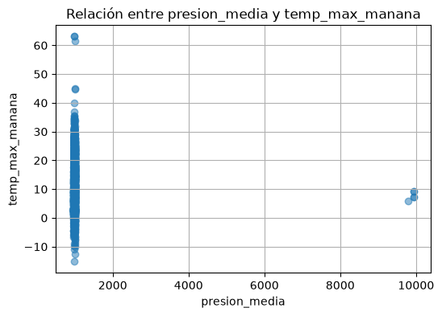

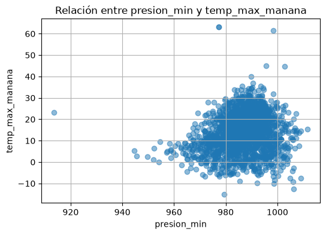

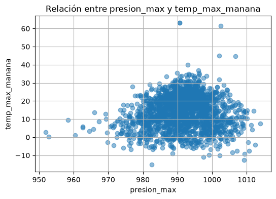

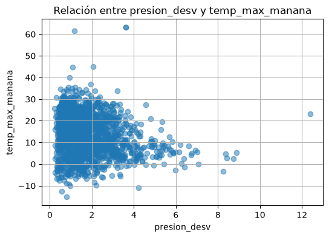

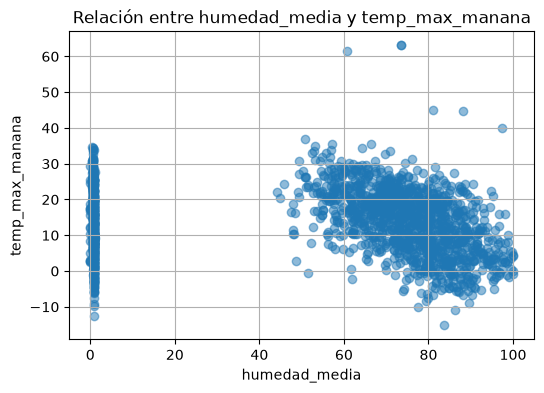

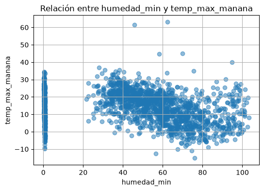

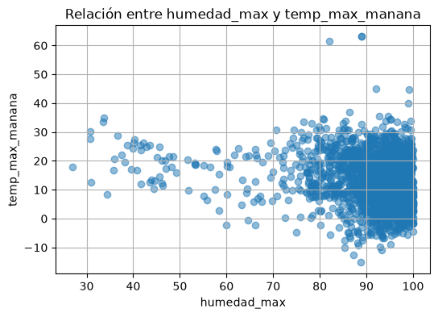

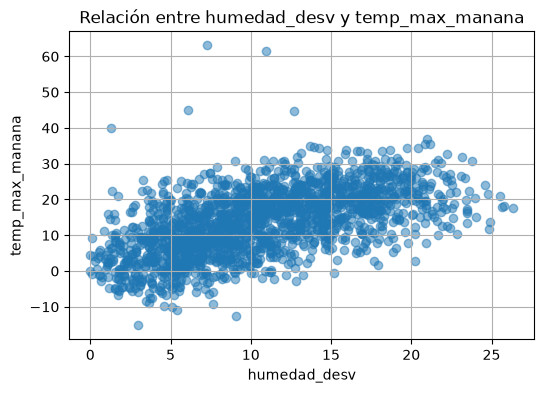

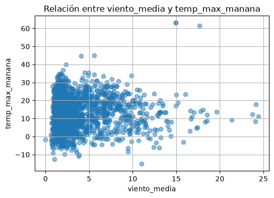

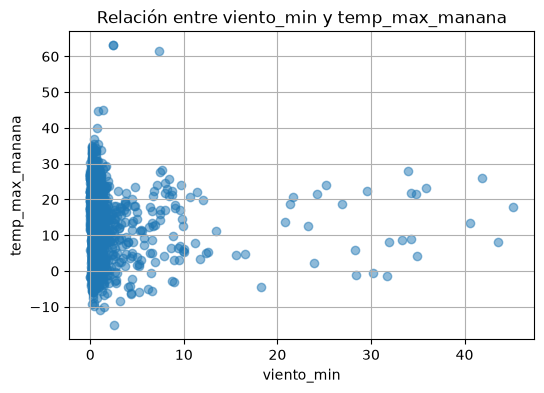

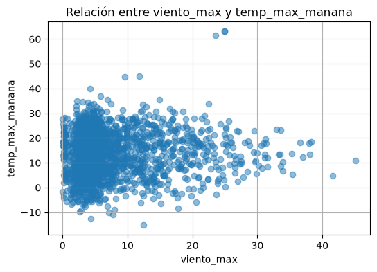

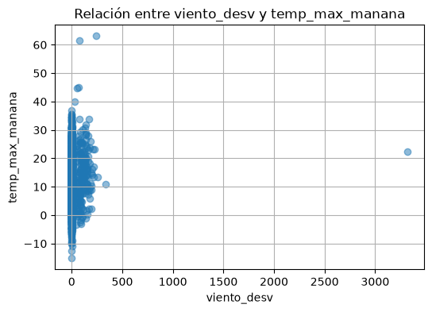

[10 more figures not shown]

```python
for variable in numeric_features_m1:
    plt.figure(figsize=(6, 4))
    plt.scatter(X_train[variable], y_train, alpha=0.5)
    plt.title(f'Relación entre {variable} y {target}')
    plt.xlabel(variable)
    plt.ylabel(target)
    plt.grid()
    plt.show()
```

Es importante darse cuenta que estas graficas son con los datos originales por lo cual salen todavia los datos atipicos que se corrigen en el pipeline.

Aparte de lo anterior, podemos ver que la mayoría de graficas parecen mostrar una relacion lineal entre las variables pero la última grafica de dia del anio parece mostrar una relacion no lineal, intentemos ofrecer una transformacion para entender esta variable de manera mas completa. Como es una relacion periodica, pues un año se repite de manera consistente podriamos pensar quizas en una transformacion periodica con funciones trigonométricas.

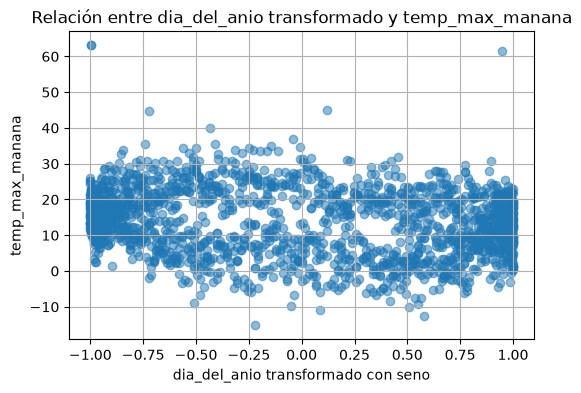

```python
#grafica entre dia del año transformada con seno y temp_max_manana
plt.figure(figsize=(6, 4))
plt.scatter(np.sin(2 * np.pi * X_train["dia_del_anio"] / 365), y_train, alpha=0.5)
plt.title(f'Relación entre {"dia_del_anio"} transformado y {target}')
plt.xlabel("dia_del_anio transformado con seno")
plt.ylabel(target)
plt.grid()
plt.show()
```

```python
#funcion para realizar transformacion de dia del año con seno
def transformar_dia_anio_seno(df):
    df = df.copy()
    df["dia_del_anio_seno"] = np.sin(2 * np.pi * df["dia_del_anio"] / 365) #esta es la misma transformacion que se hizo en la grafica anterior
    return df
```

```python
numeric_features_m3 = [
    'presion_media', 'presion_min', 'presion_max', 'presion_desv',
    'humedad_media', 'humedad_min', 'humedad_max', 'humedad_desv',
    'viento_media', 'viento_min', 'viento_max', 'viento_desv',
    'rafaga_media', 'rafaga_min', 'rafaga_max', 'rafaga_desv',
    'viento_norte', 'viento_este', 'direccion_viento',
    'registros_del_dia', 'anio', 'dia_del_anio', 'dia_del_anio_seno', #se incluye dia_del_anio_seno
]

preprocessor_m3 = ColumnTransformer(transformers=[
    ('num', numeric_transformer_m1, numeric_features_m3),#se hacen las mismas transformaciones que en m1 pero a las variables mas dia del año tranformado
    ('cat', categorical_transformer_m1, categorical_features_m1),
])
```

```python
#hagamos el pipeline con la transformacion de dia del año con seno para modelo 3
pipeline_m3 = Pipeline(steps=[
    ('dropper', dropper),
    ('normalizar_categoricas', corrector_categoricas),
    ('corregir_rangos', corrector_rangos),
    ('transformar_dia_anio_seno', FunctionTransformer(transformar_dia_anio_seno)),
    ('preprocesamiento', preprocessor_m3),  # Usamos el mismo preprocesador que en el modelo 1
    ('modelo', LinearRegression()),
])

pipeline_m3
```

```
Pipeline(steps=[('dropper',
                 FunctionTransformer(func=<function drop_columns at 0x116f396c0>)),
                ('normalizar_categoricas',
                 FunctionTransformer(func=<function normalizar_categoricas at 0x116f394e0>)),
                ('corregir_rangos',
                 FunctionTransformer(func=<function corregir_rangos_numericos at 0x116f38900>)),
                ('transformar_dia_anio_seno',
                 FunctionTransformer(func=<function tra...
                                                   'rafaga_max', 'rafaga_desv',
                                                   'viento_norte',
                                                   'viento_este',
                                                   'direccion_viento',
                                                   'registros_del_dia', 'anio',
                                                   'dia_del_anio',
                                                   'dia_del_anio_seno']),
                                                 ('cat',
                                                  Pipeline(steps=[('imputer',
                                                                   SimpleImputer(strategy='most_frequent')),
                                                                  ('onehot',
                                                                   OneHotEncoder(drop='if_binary',
                                                                                 handle_unknown='ignore'))]),
                                                  ['estacion_anio', 'mes',
                                                   'sector_viento'])])),
                ('modelo', LinearRegression())])
```

```python
#hacemos el fit del modelo 3
pipeline_m3.fit(X_train, y_train)

y_train_pred_m3 = pipeline_m3.predict(X_train)
y_test_pred_m3 = pipeline_m3.predict(X_test)

rmse_train_m3 = np.sqrt(mean_squared_error(y_train, y_train_pred_m3))
mae_train_m3 = mean_absolute_error(y_train, y_train_pred_m3)
r2_train_m3 = r2_score(y_train, y_train_pred_m3)

rmse_test_m3 = np.sqrt(mean_squared_error(y_test, y_test_pred_m3))
mae_test_m3 = mean_absolute_error(y_test, y_test_pred_m3)
r2_test_m3 = r2_score(y_test, y_test_pred_m3)

print('Modelo 3 (variables reducidas, mediana, con transformacion de dia del año)')
print(f'  Train -> RMSE: {rmse_train_m3:.4f} | MAE: {mae_train_m3:.4f} | R2: {r2_train_m3:.4f}')
print(f'  Test  -> RMSE: {rmse_test_m3:.4f} | MAE: {mae_test_m3:.4f} | R2: {r2_test_m3:.4f}')
```

[output not shown]

# 4. Tabla comparativa de rendimiento (test)

```python
tabla_comparativa = pd.DataFrame({
    'Modelo': [
        'Modelo 1 - Todas las variables (media + escalado)',
        'Modelo 2 - Variables reducidas (mediana, sin escalado)',
        'Modelo 3 - Variables reducidas (media, con transformacion de dia del año)'
    ],
    'RMSE_test': [rmse_test_m1, rmse_test_m2, rmse_test_m3],
    'MAE_test': [mae_test_m1, mae_test_m2, mae_test_m3],
    'R2_test': [r2_test_m1, r2_test_m2, r2_test_m3],
}).set_index('Modelo')

tabla_comparativa = tabla_comparativa.sort_values('RMSE_test')
tabla_comparativa.round(4)
```

[output not shown]

```python
mejor_modelo = tabla_comparativa.index[0]
print(f'Mejor modelo segun RMSE en test: {mejor_modelo}')
print(tabla_comparativa.round(4))
```

[output not shown]

Podemos ver que el modelo con mejor desempeño es el modelo 3 el cual tiene en cuenta la relacion no lineal e incluye todas las variables explicativas.

# 5. Análisis de resultados

## Analisis de coeficientes

```python
#imprimir el valor de cada coeficiente del modelo 3 y el nombre de la variable correspondiente
Modelo = pipeline_m3.named_steps["modelo"]
feature_names = pipeline_m3.named_steps["preprocesamiento"].get_feature_names_out()
feature_names = [
    name.replace("num__", "").replace("cat__", "")
    for name in feature_names
]
coef_df = pd.DataFrame({
    "Variable": feature_names,
    "Coeficiente": Modelo.coef_
})
coef_df
```

|  | Variable | Coeficiente |
| --- | --- | --- |
| 0 | presion_media | 0.958906 |
| 1 | presion_min | -0.680144 |
| 2 | presion_max | -0.515476 |
| 3 | presion_desv | -1.235264 |
| 4 | humedad_media | 0.230891 |
| 5 | humedad_min | -0.628279 |
| 6 | humedad_max | -1.083457 |
| 7 | humedad_desv | 4.144649 |
| 8 | viento_media | 0.065923 |
| 9 | viento_min | -0.117626 |
| 10 | viento_max | 0.204174 |
| 11 | viento_desv | -0.621457 |
| 12 | rafaga_media | -0.574562 |
| 13 | rafaga_min | 0.145483 |
| 14 | rafaga_max | 0.467870 |
| 15 | rafaga_desv | 1.020849 |
| 16 | viento_norte | -1.046036 |
| 17 | viento_este | -0.103258 |
| 18 | direccion_viento | -0.048098 |
| 19 | registros_del_dia | 0.114755 |
| 20 | anio | 0.907249 |
| 21 | dia_del_anio | -0.302729 |
| 22 | dia_del_anio_seno | -4.848836 |
| 23 | estacion_anio_invierno | -0.522042 |
| 24 | estacion_anio_otoño | -4.002520 |
| 25 | estacion_anio_primavera | 4.168518 |
| 26 | estacion_anio_verano | 0.356044 |
| 27 | mes_abril | 1.350173 |
| 28 | mes_agosto | -0.246413 |
| 29 | mes_diciembre | -2.554367 |
| 30 | mes_enero | -1.546792 |
| 31 | mes_febrero | -0.542786 |
| 32 | mes_julio | 2.244929 |
| 33 | mes_junio | 3.824972 |
| 34 | mes_marzo | -1.437338 |
| 35 | mes_mayo | 1.808960 |
| 36 | mes_noviembre | -1.438160 |
| 37 | mes_octubre | -1.360457 |
| 38 | mes_septiembre | -0.102722 |
| 39 | sector_viento_E | 2.309211 |
| 40 | sector_viento_N | 1.033782 |
| 41 | sector_viento_NE | 1.052298 |
| 42 | sector_viento_NO | -1.537937 |
| 43 | sector_viento_O | 0.341293 |
| 44 | sector_viento_S | -1.474582 |
| 45 | sector_viento_SE | -1.134668 |
| 46 | sector_viento_SO | -0.589396 |

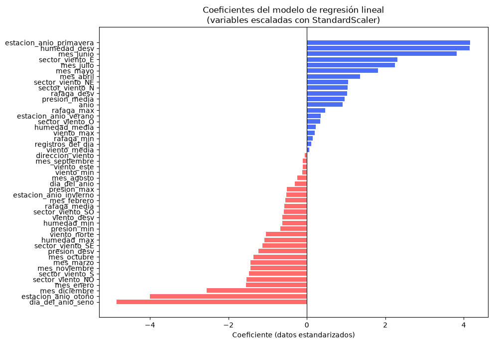

[output not shown]

```python
#graficar los coeficientes del modelo 3
# Visualización de coeficientes ordenados
coef_sorted = coef_df.sort_values('Coeficiente')
colors = ['#FF6B6B' if c < 0 else '#4C6EF5' for c in coef_sorted['Coeficiente']]

plt.figure(figsize=(10, 7))
plt.barh(coef_sorted['Variable'], coef_sorted['Coeficiente'], color=colors)
plt.axvline(0, color='black', linewidth=0.8)
plt.xlabel('Coeficiente (datos estandarizados)')
plt.title('Coeficientes del modelo de regresión lineal\n(variables escaladas con StandardScaler)')
plt.tight_layout()
plt.show()
print("🔵 Azul = efecto positivo en el precio  |  🔴 Rojo = efecto negativo")
print("Como estandarizamos las variables los coeficientes son comparables entre sí, y nos permiten ver la importancia relativa de cada variable en la predicción de la temperatura máxima del día siguiente.")
```